# DATA 605 : Final Exam

### 4. What is the frequency distribution of the numbers in the dataset?

#### Answer :

Frequency Distribution : A frequency distribution is a representation, either in a graphical or tabular format, that displays the number of observations within a given interval or categories. It is also called the Frequency Distribution table. Given this dataset, frequency distribution table shows occurrence of various labels in training dataset. To investigate the balance of the data for each label, function will plot all of them along with their name. A plot for the same is below

```r
# Table shows numeric representation of frequency distribution
table(train$label)
```

```
##
##    0    1    2    3    4    5    6    7    8    9
## 4132 4684 4177 4351 4072 3795 4137 4401 4063 4188
```

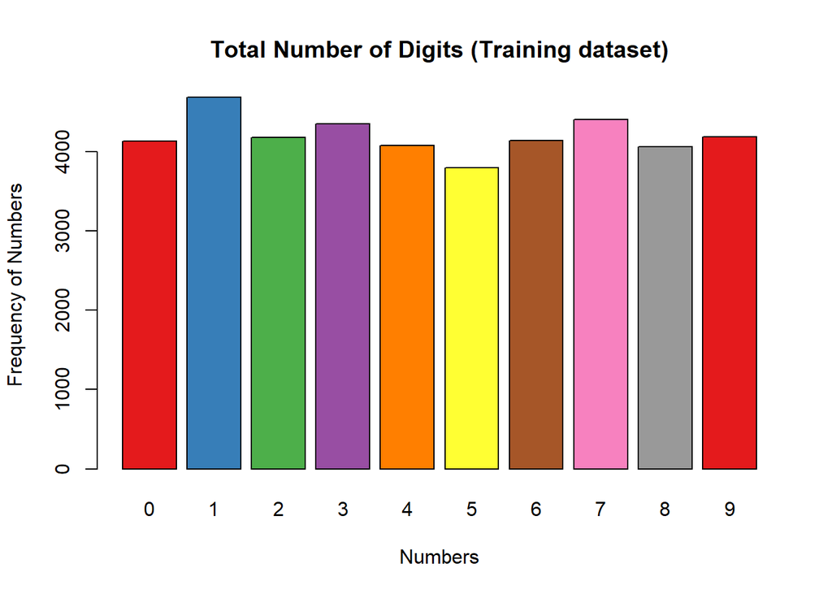

```r
# Bar plot chart to show frequency distribution
barplot(table(train$label), main="Total Number of Digits (Training dataset)", col=brewer.pal(10,"Set1"),
    xlab="Numbers", ylab = "Frequency of Numbers")
```

### 5. For each number, provide the mean pixel intensity. What does this tell you?

#### Answer :

To find mean pixel intensity of all of the pixels, we can reshape the dataframe. The output is actually a series, indexed by the original index as well as the pixel label:

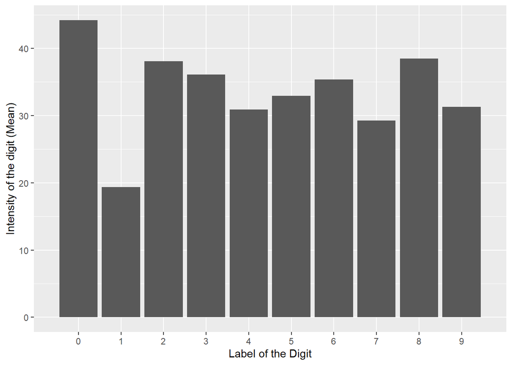

```r
# Lets calculate mean of each row in training data set to find pixel intensity of all of the pixels
train$intensity <- apply(train[,-1], 1, mean)
intensity_by_label <- aggregate (train$intensity, FUN = mean, by = list(train$label))
# Now lets plot intensity_by_label
ggplot(data=intensity_by_label, aes(x=Group.1, y = x)) +
    geom_bar(stat="identity")+scale_x_discrete(limits=0:9) + xlab("Label of the Digit") +
    ylab("Intensity of the digit (Mean)")
```

Lets plot Histogram for 0, 8, 2, 6

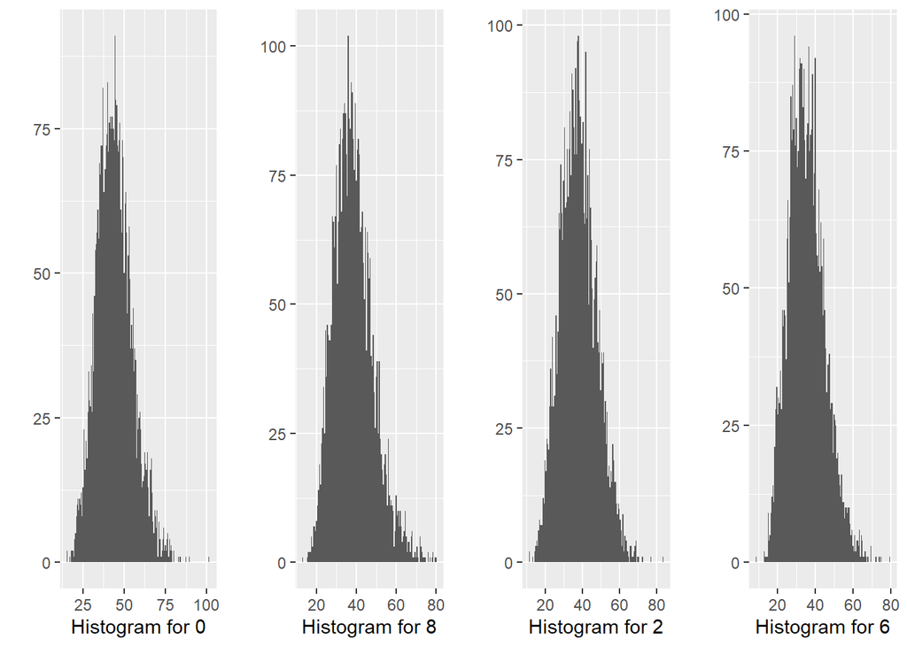

```r
grid.arrange(qplot(subset(train, label ==0)$intensity, binwidth = .5, xlab = "Histogram for 0"),
qplot(subset(train, label ==8)$intensity, binwidth = .5, xlab = "Histogram for 8"),
qplot(subset(train, label ==2)$intensity, binwidth = .5, xlab = "Histogram for 2"),
qplot(subset(train, label ==6)$intensity, binwidth = .5, xlab = "Histogram for 6"),ncol = 4)
```

[figure not shown]

```r
grid.arrange(qplot(subset(train, label ==0)$intensity, binwidth = .5, xlab = "Histogram for 1"),
qplot(subset(train, label ==8)$intensity, binwidth = .5, xlab = "Histogram for 4"),
qplot(subset(train, label ==2)$intensity, binwidth = .5, xlab = "Histogram for 7"),
qplot(subset(train, label ==6)$intensity, binwidth = .5, xlab = "Histogram for 9"),ncol = 4)
```

### 6. Reduce the data by using principal components that account for 95% of the variance. How many components did you generate? Use PCA to generate all possible components (100% of the variance). How many components are possible? Why?

#### Answer :

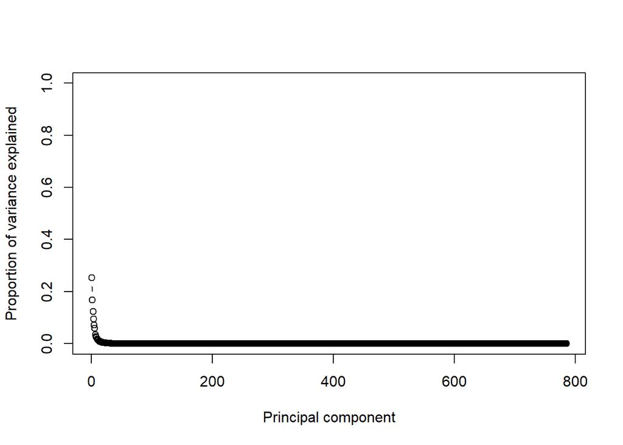

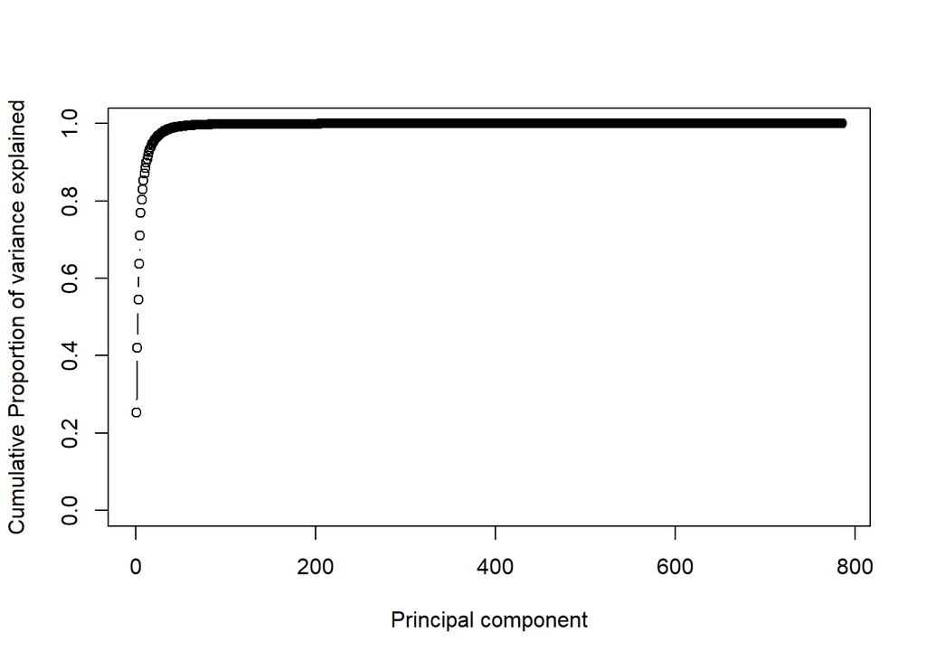

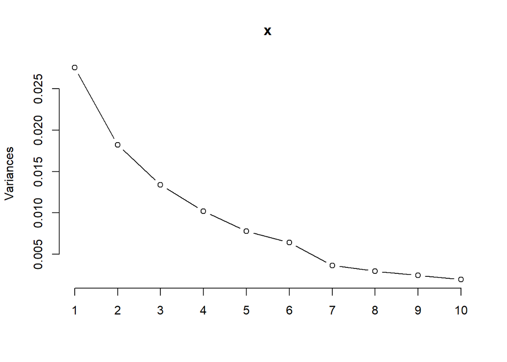

```r
pcaCharts <- function(x) {
    x.var <- x$sdev ^ 2
    x.pvar <- x.var/sum(x.var)
    par(mfrow=c(1,1))
    plot(x.pvar,xlab="Principal component", ylab="Proportion of variance explained", ylim=c(0,1), type='b')
    plot(cumsum(x.pvar),xlab="Principal component", ylab="Cumulative Proportion of variance explained", ylim=c(0,1), type='b')
    screeplot(x,type="l")
    par(mfrow=c(1,1))
}

#Reducing data using PCA
train_norm<-as.matrix(train[,-1])/255
train_norm_cov <- cov(train_norm)
pca <- prcomp(train_norm_cov)

pcaCharts(pca)
```

```r
# Calculate the variance explained by each principal component
variance_explained<-as.data.frame(pca$sdev^2/sum(pca$sdev^2))
variance_explained<-cbind(1:785, cumsum(variance_explained))
colnames(variance_explained)<-c("Number", "Variance")
variance_explained<-as.data.frame(variance_explained)
variance_explained
```

```
##     Number  Variance
## 1        1 0.2533019
## 2        2 0.4211143
## 3        3 0.5443375
## 4        4 0.6382797
## 5        5 0.7099622
## 6        6 0.7691849
## 7        7 0.8028326
## 8        8 0.8302254
## 9        9 0.8531247
## 10      10 0.8711668
## 11      11 0.8853364
## 12      12 0.8986528
## 13      13 0.9080900
## 14      14 0.9174678
```

[output cut: 771 more lines]

There are around 20 components generated at 95% of variance

### 7. Plot the first 10 images generated by PCA. They will appear to be noise. Why?

#### Answer :

Because PCs of higher eigenvalues to show more generic features.The specialized features are also being added for more PCs. So removing removing some PCs with lower eigenvalues actually acting as some sort of regularization and your model is only learning the more general features. If you take all of them the 100% of the data-variations will be restored like the original dimensions.

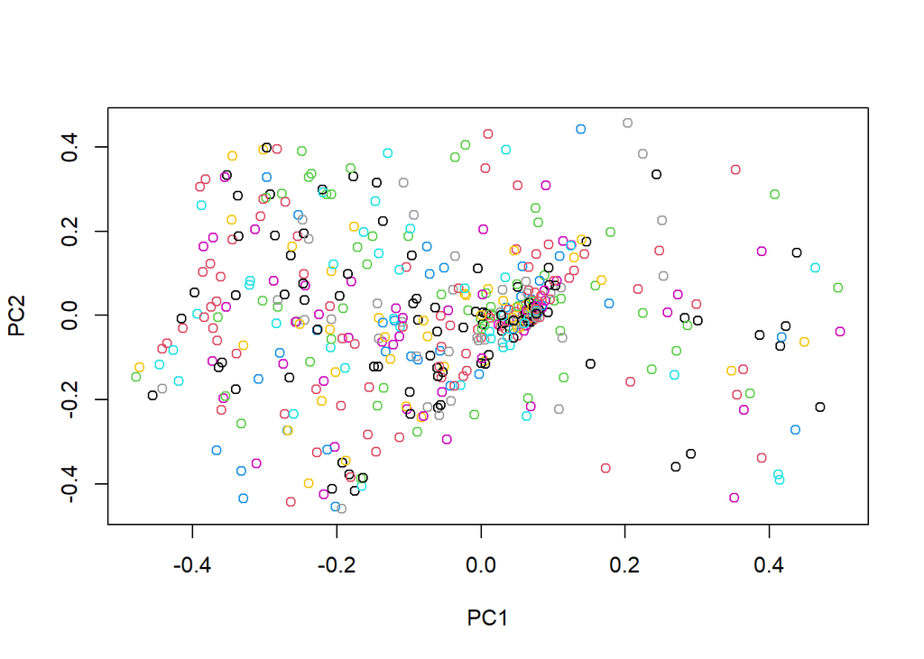

```r
labelClasses <- factor(train$label)
plot(main="",pca$x, col = labelClasses)
```

```r
for(i in 1:10){
  digit(pca$x[i, -1])
}
```

[figure not shown]

### 8. Now, select only those images that have labels that are 8’s. Re-run PCA that accounts for all of the variance (100%). Plot the first 10 images. What do you see?

#### Answer :

```r
train_sub_8<-subset(train, label ==8)
nrow(train_sub_8)
```

```
## [1] 4063
```

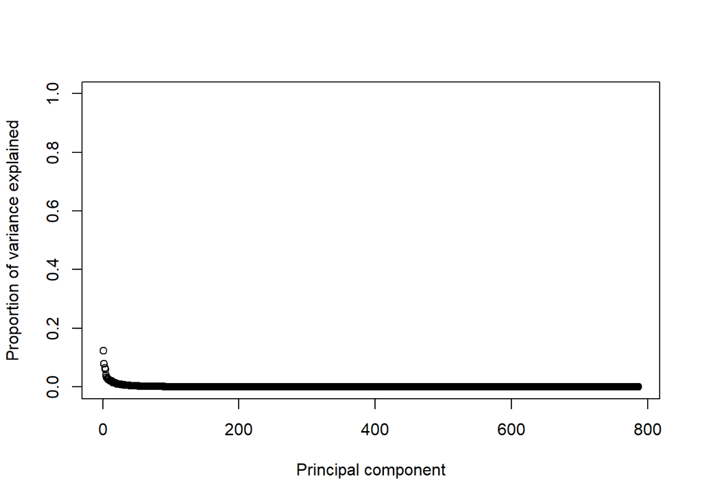

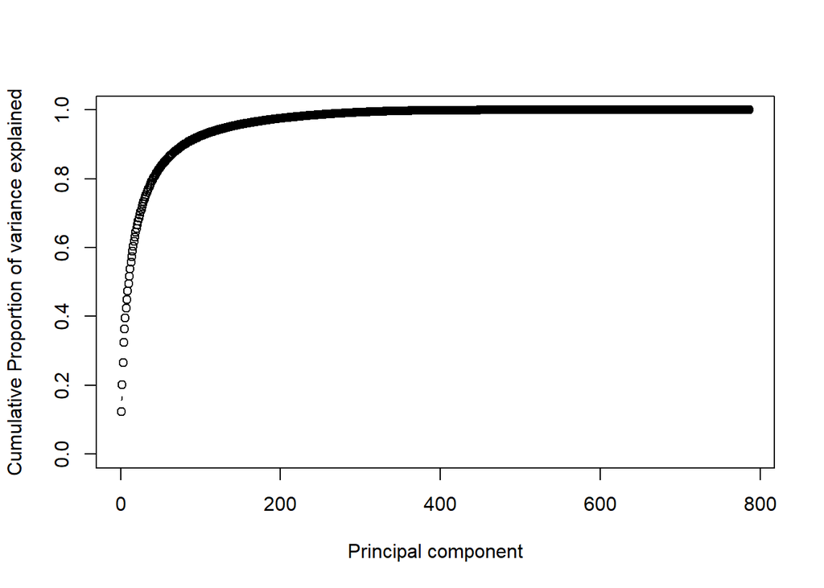

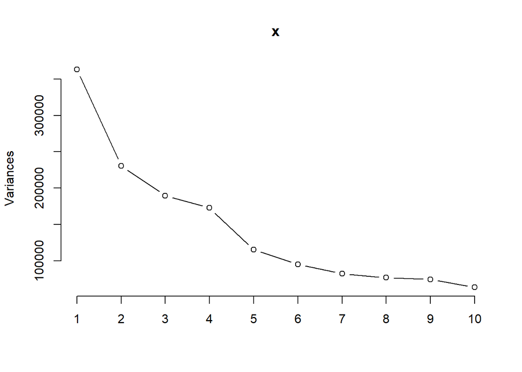

```r
pca <- prcomp(train_sub_8)
pcaCharts(pca)
```

```r
par(mfrow=c(3,4))
for(i in 1:10){
  digit(train_sub_8[i, -1])
}
```

[figure not shown]

In above images, different type of 8 letters seems to be visible. ***

#### Answer :

Lines below for this model are commented, this model for 42K records takes around 4 days of time to return the results.

#### Answer :

```r
train <- read.csv("train1.csv")

train[is.na(train)] <- 0
sample_size = round(nrow(train)*.70) # setting what is 70%
index <- sample(seq_len(nrow(train)), size = sample_size)

train <- train[index, ]
test <- train[-index, ]

#Build Multinomial Model
#multinomModel <- multinom(label ~., family = "multinomial", data = train, MaxNWts =100000, maxit=10);
#summary (multinomModel) # model summary

#predicted_scores <- predict (multinomModel, test, "probs") # predict on multinomModel data
#predicted_class <- predict (multinomModel, test) # model summary

#Confusion Matrix and Misclassification Error
#table(predicted_class, test$label)
#mean(as.character(predicted_class) != as.character(test$label))
```

*** Gradient boosted trees model for multinomial *** : Gradient boosting is a machine learning technique used in regression and classification tasks, among others. It gives a prediction model in the form of an ensemble of weak prediction models, which are typically decision trees. Gradient boosted trees also run directly on the multiclass labels. The model performs much better if I increase the interaction depth slightly. Increasing it past 2-3 is beneficial in large models, but rarely useful with smaller cases like this. I could also play with the learning rate, but won’t fiddle with that here for now.

```r
# Model fitting
Xtrain <- as.matrix(train)
Xtest <- as.matrix(test)
ytrain <- train[,1]
ytest <- test[,1]
gbm_result <- gbm.fit(Xtrain,  factor(ytrain), distribution="multinomial", n.trees=500, interaction.depth=2)
#summary(gbm_result)
gbm_prediction <- apply(predict(gbm_result, Xtest, n.trees=gbm_result$n.trees),1,which.max) - 1L
# Prediction
gbm_prediction
```

```
##  [1] 7 7 6 5 2 2 8 7 9 3 2 0 2 5 2 9 8 4 2 5 3 8 6 3 6 8 5 8 2 8 2 0 3 6 6 0 7 2
## [39] 6 3 6 7 0 3 9 7 2 0 4 0 4 1 2 6 1 0 8 1 4 6 2 4 9 6 6 2 4 0 7 1 8 1 9 8 3 5
## [77] 2 2 1 3 5 3 5 1 3 7 8 9 2 6
```

Lets try Ridge regression for prediction and confusion, I’ll directly use the multinomial loss function and let the R function do cross validation this time.

```r
library(glmnet)
outLm <- cv.glmnet(Xtrain, ytrain, alpha=0, nfolds=3,
                    family="multinomial")
outLm
```

```
##
## Call:  cv.glmnet(x = Xtrain, y = ytrain, nfolds = 3, alpha = 0, family = "multinomial")
##
## Measure: Multinomial Deviance
##
##     Lambda Index Measure      SE Nonzero
## min  1.890   100   2.338 0.07591     563
## 1se  2.173    97   2.396 0.07489     563
```

```r
predLm <- apply(predict(outLm, Xtest, s=outLm$lambda.min,
                  type="response"), 1, which.max) - 1L
predLm
```

```
##  19 117  22 218  35 362 247 387 211 395  95 345  23   9 303 188 319 146 105 163
##   7   7   6   6   2   2   8   7   9   3   2   0   2   5   2   4   8   4   2   5
## 315 177 165 241 347 332 175 221 248 155 102 328 285 128  73 358 127 200  90 220
##   3   8   1   3   6   8   5   8   2   8   2   0   3   6   6   0   7   2   6   3
## 400  77 252  14  86 224 170 287 149 404 333 336 366  65  97 189  68   1 123 271
##   6   7   6   3   9   7   2   0   4   0   4   1   2   6   1   0   8   1   4   6
## 295  33  28 180 375 242  50 204 121 256  11 153 263 396 226 168 411 208 282 321
##   2   4   9   6   6   2   4   0   7   1   8   1   9   8   3   5   2   2   1   3
## 302 233 392  16  71 294 378 339 361 195
##   5   3   5   1   3   7   6   9   1   6
```

```r
#Mis-classification rates by class
tapply(predLm != ytest, ytest, mean)
```

```
##          0          1          2          3          4          5          6
## 0.12500000 0.00000000 0.06250000 0.00000000 0.00000000 0.00000000 0.07692308
##          7          8          9
## 0.00000000 0.10000000 0.16666667
```

```r
# Confusion Metric
table(predLm,ytest)
```

```
##       ytest
## predLm  0  1  2  3  4  5  6  7  8  9
##      0  7  0  0  0  0  0  0  0  0  0
##      1  0  7  1  0  0  0  1  0  0  0
##      2  0  0 15  0  0  0  0  0  0  0
##      3  0  0  0 10  0  0  0  0  0  0
##      4  0  0  0  0  6  0  0  0  0  1
##      5  0  0  0  0  0  6  0  0  0  0
##      6  1  0  0  0  0  0 12  0  1  0
##      7  0  0  0  0  0  0  0  8  0  0
##      8  0  0  0  0  0  0  0  0  9  0
##      9  0  0  0  0  0  0  0  0  0  5
```

We might think that a lot 6’s and 9’s are being mis-classified as one another (they do look similar in some ways). Looking at the confusion matricies we see that this is not quite the case.